# 8.1

The goal of reinforcement learning is to determine the optimal approach for making a series of decisions over time in a dynamic environment. In contrast, supervised learning entails generating one or more predictions based on features at a specific moment in time.

# 8.2

Exploitation refers to selecting the best possible action discovered thus far, while exploration entails choosing a different action at random. If an algorithm relies solely on exploitation after a few attempts, it may miss out on discovering the optimal action. Conversely, if the algorithm solely relies on exploration, it won't be able to leverage what it has learned.

# 8.3

Dynamic programming is a technique that involves computing the optimal action for each possible state by working backwards from the horizon date to the initial stage.

# 8.4

The best possible approach is to ensure that your opponent is left with a total of 4n+1 matches, where n represents an integer. For instance, if there are 8 matches, the optimal strategy would be to pick up 3 matches. Although this tactic has been identified as the most effective strategy after 1,000 trials, the evidence is not entirely conclusive. However, after 5,000 and 10,000 trials, the superior decision-making strategies become increasingly apparent.

# 8.5

During a Monte Carlo simulation, every trial encompasses a blend of exploration and exploitation. The latest observation regarding the potential benefits of performing a specific action in a given state is determined by calculating the total future reward from the moment the action was executed until the horizon date, which may involve discounting.

# 8.6

Temporal difference learning requires both exploration and exploitation during each trial. To determine the value of a specific action in a given state, a new observation is made by looking one period ahead and utilizing the most up-to-date estimation of the state's value that will be reached.

# 8.11

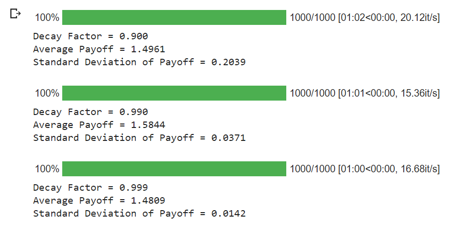

# 8.12

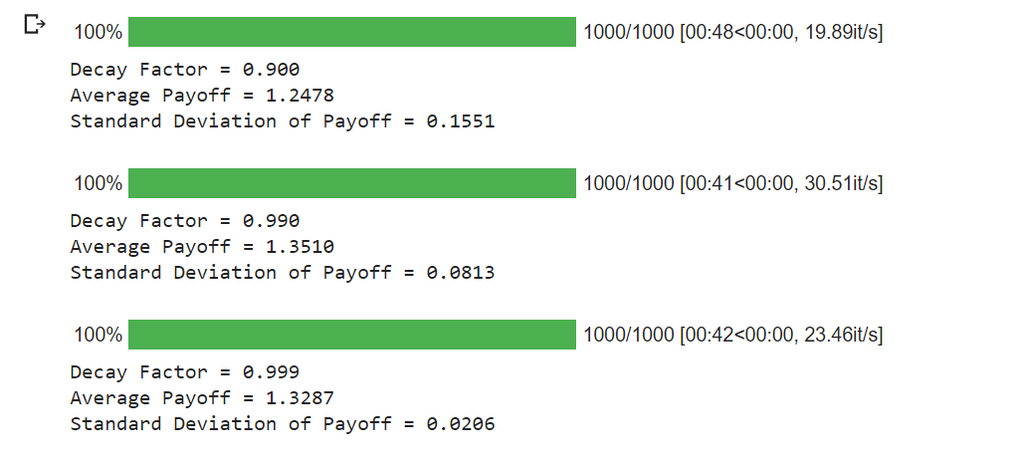

# 8.13

# See the attached excel named 8.13, i have moved the authors' code into one file and the calculation is set to manual Please press F9 for recalculation.

At a decay factor of 0.9995, random Monte Carlo, the algorithm will never learn that picking up three matches when it is eight matches will win (250,500, 1000 trials) At a decay factor of 0.995, random Monte Carlo, the algorithm will learn that picking up three matches when it is eight matches will win at 1000 trials, but it is inconsistency since it will not always arrive at the same conclusion

At a decay factor of 0.9995, the opponent learns Monte Carlo. The algorithm will never learn that picking up three matches when it is eight matches will win (250,500, 1000 trials) At a decay factor of 0.995, the opponent learns Monte Carlo, and the algorithm will learn that picking up three matches when it is eight matches will win at 1000 trials, but it is inconsistency since it will not always arrive at the same conclusion

Hence both methods have the same result

# 8.14

## See the attached excel named 8.14, i have moved the authors' code into one file and the calculation is set to manual Please press F9 for recalculation.

## or for pyton in pdf named 8.14

MC random: At a decay factor of 0.9995, random Monte Carlo,the algorithm will never learn how many matches to pick when there is 22 matches in order to win(1000,2500, 5000, 10000 trials)

MC learn: At a decay factor of 0.9995, opponent learns Monte Carlo,the algorithm will never guarantee to learn how many matches to pick when there is 22 matches in order to win(1000,2500, 5000, 10000 trials), but once a while it will learn that picking up 1 match will win when there is 22 matches on the table(10000 trials)

TD random: At a decay factor of 0.9995, opponents play random temporal difference learning, the algorithm will never learn how many matches to pick when there is 22 matches in order to win(1000,2500, 5000, 10000 trials)

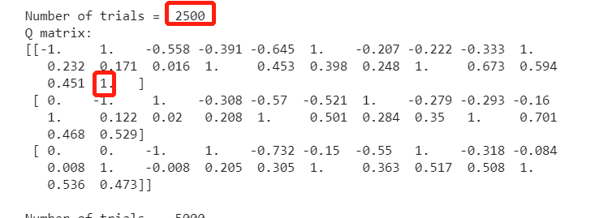

TD learn: At a decay factor of 0.9995, opponents learn temporal difference learning, the algorithm will consistently learn that picking up 1 match when there are 22 matches on the table will win with 2500 trials and above

Overall, the TD learning methods (learned) were the more effective at learning to play the game of Nim than the Monte Carlo methods(learned). The TD methods are stable and reliable, with consistence results starting at 2500 trials. However, it's important to note that the performance of the methods may vary depending on the specific problem and the chosen hyperparameters.

# 8.15

## See the attached excel named 8.15, i have moved the authors' code into one file and the calculation is set to manual Please press F9 for recalculation.

## or for pyton in pdf named 8.15

MC random: At a decay factor of 0.9995, random Monte Carlo, the algorithm will never learn how many matches to pick when there is 27 matches in order to win(1000,2500, 5000, 10000 trials)

MC learn: At a decay factor of 0.9995, opponent learns Monte Carlo,the algorithm will never guarantee to learn how many matches to pick when there is 27 matches in order to win(1000,2500, 5000, 10000 trials), but once a while it will learn that picking up 2 matches will win when there is 27 matches on the table(10000 trials)

TD random: At a decay factor of 0.9995, opponents play random temporal difference learning, the algorithm will never learn how many matches to pick when there is 27 matches in order to win(1000,2500, 5000, 10000 trials)

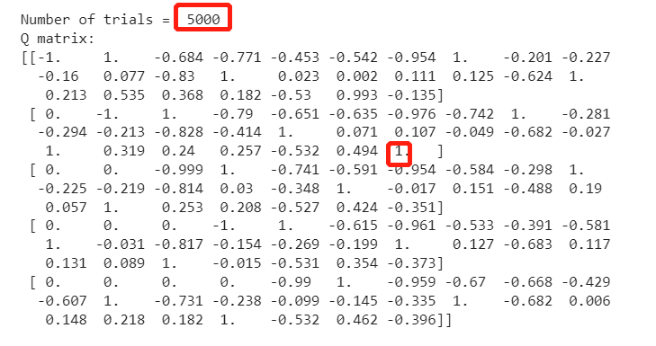

TD learn: At a decay factor of 0.9995, opponents learn temporal difference learning, the algorithm will consistently learn that picking up 2 matches when there are 27 matches on the table will win with 10000 trials and above, but will start to show a promisisng amount of 2 matches around 2500 trials

# 8.16

## a) M=6

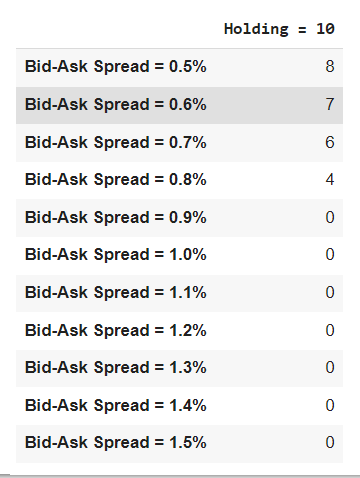

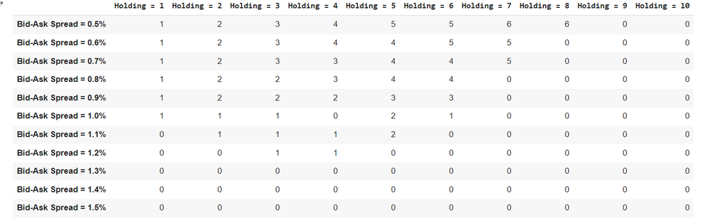

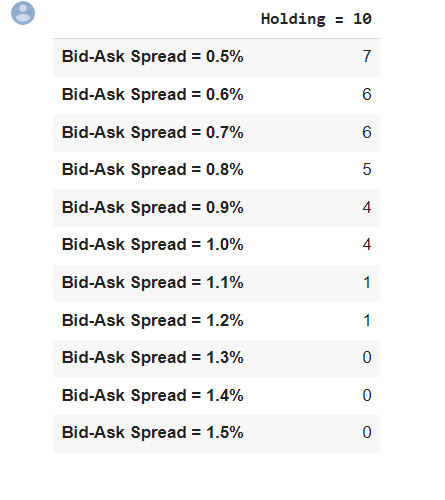

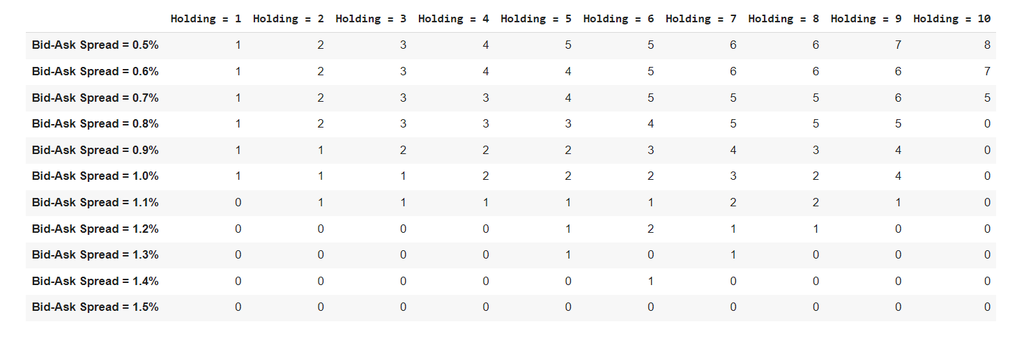

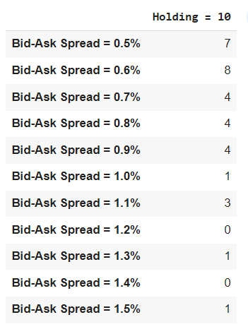

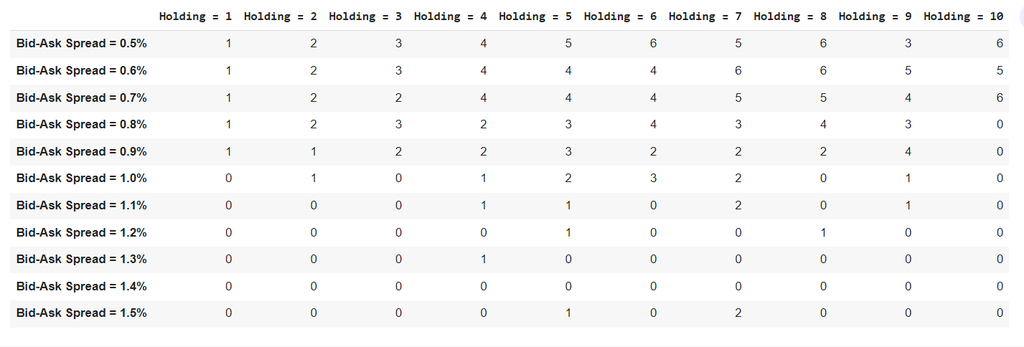

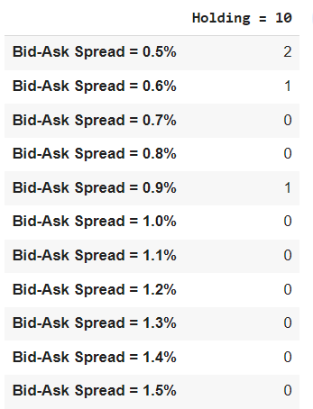

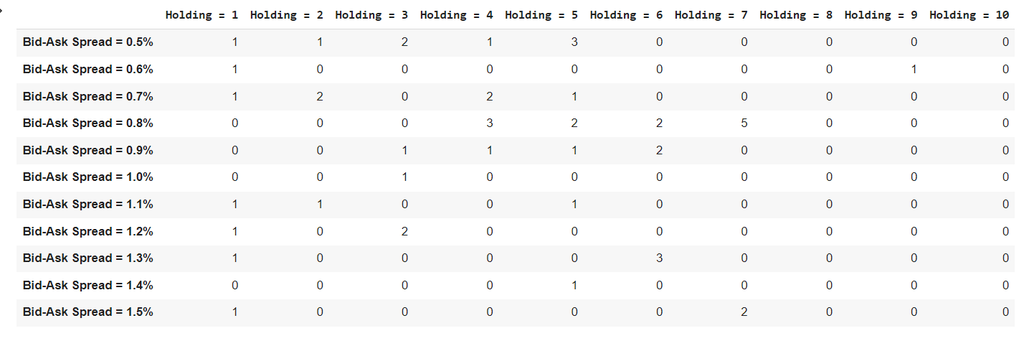

Changing the number of days from 10 to 6: RL: Average bid-ask spread paid(%): 0.48466525000000005 RL: Standard Deviation of bid-ask spread paid(%): 0.34196512350302266 Linear Execution: Average bid-ask spread paid(%): 0.6301769 Linear Execution: Standard Deviation of bid-ask spread paid(%): 0.077195062707339 Conclusion: Reducing the number of days from 10 to 6 has slightly increased the average bid-ask spread paid by the RL algorithm and also increased the standard deviation.

Changing small-trade bid-mid spreads from 11 to 15: RL: Average bid-ask spread paid(%): 0.8792724000000002 RL: Standard Deviation of bid-ask spread paid(%): 0.17934719846777647 Linear Execution: Average bid-ask spread paid(%): 1.0498184000000002 Linear Execution: Standard Deviation of bid-ask spread paid(%): 0.1002887582007076 Conclusion: Increasing the small-trade bid-mid spreads from 11 to 15 has slightly decreased the average bid-ask spread paid by the RL algorithm and slightly increased the standard deviation.

Changing alpha from 0.01 to 0.005: RL: Average bid-ask spread paid(%): 0.31610520000000003 RL: Standard Deviation of bid-ask spread paid(%): 0.35992920975236226 Linear Execution: Average bid-ask spread paid(%): 0.5248961000000001 Linear Execution: Standard Deviation of bid-ask spread paid(%): 0.07055865790099752 Conclusion: Decreasing the value of alpha from 0.01 to 0.005 has slightly decreased the average bid-ask spread paid by the RL algorithm and slightly increased the standard deviation.

Changing beta from 0.99999999 to 0.85: RL: Average bid-ask spread paid(%): 0.10502090000000001 RL: Standard Deviation of bid-ask spread paid(%): 0.031645356107808296 Linear Execution: Average bid-ask spread paid(%): 1.0503976000000002 Linear Execution: Standard Deviation of bid-ask spread paid(%): 0.09991253131734777 Conclusion: Changing the value of beta from 0.99999999 to 0.85 has significantly decreased the average bid-ask spread paid by the RL algorithm, with a much lower standard deviation.

# 8.17

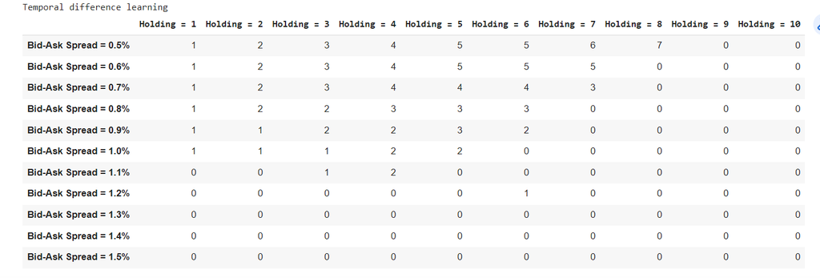

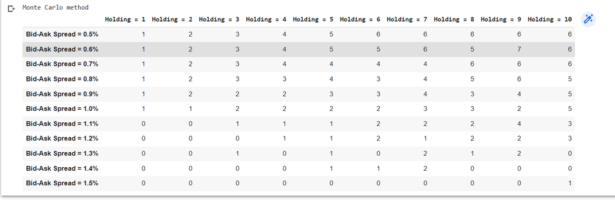